# Phase 8: Mouse→Human Ortholog Conversion Table

**Purpose**: Create a reliable mm10→hg38 1:1 ortholog table using Ensembl BioMart REST API.  
This table is required by Phase 9 (Human Trajectory) to convert the Mouse Sham signature to Human gene names.

**Steps**:

1. Download mm10→hg38 ortholog table via Ensembl BioMart XML query
2. Filter to 1:1 orthologs with high identity (ortholog_one2one)
3. Apply to Mouse Sham signature (Phase 7 output) → Human gene names
4. Apply to Mouse pySCENIC TCF4 targets (18 genes) → Human gene names
5. Verify overlap with Human pySCENIC TCF4 targets (15 genes)
6. Save `mouse_human_orthologs.csv` + `human_sham_sig_genes.csv`

**Environment**: `scrna-main-2026Feb`

```
Paths OK
```

## 1. Download Mouse→Human Orthologs via Ensembl BioMart

Ensembl BioMart REST API (XML query) を使用。ネットワーク接続が必要。  
既にダウンロード済みの場合はキャッシュを使用する。

```
Loading cached ortholog table: /Volumes/KT4TB_UG/Scanpy/Human_RV_Paper_Analysis/02_data/mouse/mouse_human_orthologs_raw.tsv
Raw table: (83453, 7)
['Gene stable ID', 'Gene name', 'Human gene stable ID', 'Human gene name', 'Human homology type', '%id. target Human gene identical to query gene', '%id. query gene identical to target Human gene']
       Gene stable ID Gene name Human gene stable ID Human gene name  \
0  ENSMUSG00000064336     mt-Tf                  NaN             NaN
1  ENSMUSG00000064337   mt-Rnr1                  NaN             NaN
2  ENSMUSG00000064338     mt-Tv                  NaN             NaN
3  ENSMUSG00000064339   mt-Rnr2                  NaN             NaN
4  ENSMUSG00000064340    mt-Tl1                  NaN             NaN

  Human homology type  %id. target Human gene identical to query gene  \
0                 NaN                                             NaN
1                 NaN                                             NaN
2                 NaN                                             NaN
3                 NaN                                             NaN
4                 NaN                                             NaN

   %id. query gene identical to target Human gene
0                                             NaN
1                                             NaN
2                                             NaN
3                                             NaN
4                                             NaN
```

## 2. Build Clean 1:1 Ortholog Table

```
Orthology types:
orthology_type
ortholog_one2one      17187
ortholog_many2many     5463
ortholog_one2many      2789
Name: count, dtype: int64

1:1 orthologs: 17104 pairs
        mouse_ensembl mouse_gene    human_ensembl human_gene  \
0  ENSMUSG00000064341     mt-Nd1  ENSG00000198888     MT-ND1
1  ENSMUSG00000064345     mt-Nd2  ENSG00000198763     MT-ND2
2  ENSMUSG00000064351     mt-Co1  ENSG00000198804     MT-CO1
3  ENSMUSG00000064354     mt-Co2  ENSG00000198712     MT-CO2
4  ENSMUSG00000064356    mt-Atp8  ENSG00000228253    MT-ATP8
5  ENSMUSG00000064357    mt-Atp6  ENSG00000198899    MT-ATP6
6  ENSMUSG00000064358     mt-Co3  ENSG00000198938     MT-CO3
7  ENSMUSG00000064360     mt-Nd3  ENSG00000198840     MT-ND3
8  ENSMUSG00000065947    mt-Nd4l  ENSG00000212907    MT-ND4L
9  ENSMUSG00000064363     mt-Nd4  ENSG00000198886     MT-ND4

     orthology_type  perc_id_mouse  perc_id_human
0  ortholog_one2one        77.0440        77.0440
1  ortholog_one2one        57.3913        57.0605
2  ortholog_one2one        90.6615        90.8382
3  ortholog_one2one        71.3656        71.3656
4  ortholog_one2one        46.2687        45.5882
5  ortholog_one2one        75.6637        75.6637
6  ortholog_one2one        86.9732        86.9732
7  ortholog_one2one        66.0870        66.0870
8  ortholog_one2one        66.3265        66.3265
9  ortholog_one2one        66.8845        66.8845
```

```
Mouse genes with >1 human ortholog (after one2one filter): 1
Human genes with >1 mouse ortholog (after one2one filter): 5

Strict 1:1 orthologs: 17085 pairs
mouse→human dict: 17085 entries
human→mouse dict: 17085 entries

✓ Saved: /Volumes/KT4TB_UG/Scanpy/Human_RV_Paper_Analysis/02_data/mouse/mouse_human_orthologs.csv
```

## 3. Apply to Mouse Sham Signature (Phase 7 Output)

```
Mouse Sham signature: 100 genes
['Aqp1', 'Zbtb16', 'Timp4', 'Cav1', 'Per2', 'Bmp6', 'Ablim3', 'Cavin1', 'Xdh', 'Ablim1', 'Pakap-1', 'Meox2', 'Serinc3', 'Tspan7', 'Pdzd2', 'Sult1a1', 'Cped1', 'Dach1', 'Auts2', 'Samd5']

Converted to human: 92/100 genes
Not converted (no 1:1 ortholog): 8
  → ['Pakap-1', 'Sult1a1', 'Gstt2', 'C1qtnf9', 'Adh1', 'Slc28a2', 'Aqp7', 'Fam102b']

Human Sham signature genes:
['AQP1', 'ZBTB16', 'TIMP4', 'CAV1', 'PER2', 'BMP6', 'ABLIM3', 'CAVIN1', 'XDH', 'ABLIM1', 'MEOX2', 'SERINC3', 'TSPAN7', 'PDZD2', 'CPED1', 'DACH1', 'AUTS2', 'SAMD5', 'CYP4B1', 'PIM3', 'HSPA12B', 'USHBP1', 'ADGRF5', 'EEPD1', 'CDH23', 'TMSB4Y', 'CAVIN2', 'BCL2L1', 'TXNIP', 'FRY']
```

```
Human vascular EC adata: (7637, 17064)

Human Sham sig genes found in human adata: 92/92
['AQP1', 'ZBTB16', 'TIMP4', 'CAV1', 'PER2', 'BMP6', 'ABLIM3', 'CAVIN1', 'XDH', 'ABLIM1', 'MEOX2', 'SERINC3', 'TSPAN7', 'PDZD2', 'CPED1', 'DACH1', 'AUTS2', 'SAMD5', 'CYP4B1', 'PIM3']

✓ Saved: /Volumes/KT4TB_UG/Scanpy/Human_RV_Paper_Analysis/02_data/mouse/human_sham_sig_genes.csv
```

## 4. Apply to Mouse pySCENIC TCF4 Targets (18 Genes)

```
Mouse TCF4 targets → Human:
  Arap3           → ARAP3
  Arhgap27        → ARHGAP27
  Ccdc85a         → CCDC85A
  Dgkh            → DGKH
  Dgkz            → DGKZ
  Dock4           → DOCK4
  Egfl7           → EGFL7
  Etl4            → KIAA1217
  Exoc3l          → EXOC3L1
  Fam53b          → FAM53B
  Fhod1           → FHOD1
  Git2            → GIT2
  Plxnd1          → PLXND1
  Ptprm           → PTPRM
  Rasgrp3         → RASGRP3
  Sema6d          → SEMA6D
  Sipa1           → SIPA1
  Ushbp1          → USHBP1

Converted: 18/18 genes
```

## 5. Cross-species TCF4 Target Overlap

Mouse pySCENIC TCF4 targets (18) → ortholog変換 → Human TCF4 targets (15) との重複を Fisher's exact test で検証。

```
=== Cross-species TCF4 Regulon Target Overlap ===
Mouse TCF4 targets (mm10):        18 genes
  → converted to human:           18 genes
Human TCF4 targets (hg38):        15 genes

Overlap (Mouse→Human ∩ Human):     0 genes
Shared targets: []

Fisher exact: OR=0.00, p=1.0000
⚠ Overlap not statistically significant (may need more targets or broader background)
```

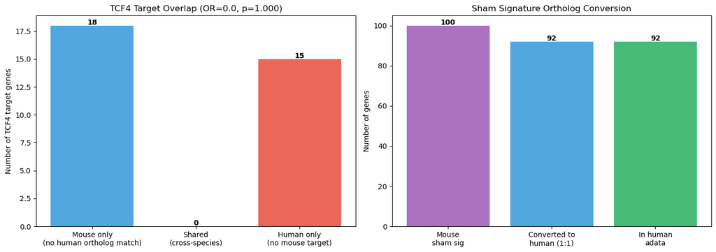

## 6. Verify Human Sham Signature on Human Data

Human Sham signature score を Human Vascular EC adata で計算し、Preserved/Reduced 分布を確認。  
Preserved群でスコアが高ければ、Cross-species root定義の妥当性が示される。

```
human_sham_sig_score added.
            count      mean       std       min       25%       50%       75%  \
condition
Preserved  3788.0  0.553733  0.176727  0.003824  0.434117  0.559475  0.682063
Reduced    3849.0  0.621062  0.179984  0.017676  0.510379  0.631396  0.749398

                max
condition
Preserved  1.092022
Reduced    1.176891

Human Sham Sig Score: Preserved vs Reduced
  Preserved mean: 0.5537
  Reduced mean:   0.6211
  Mann-Whitney U p=1.00e+00, Cohen's d=-0.377
⚠ Check: Sham signature may need refinement for human application
```

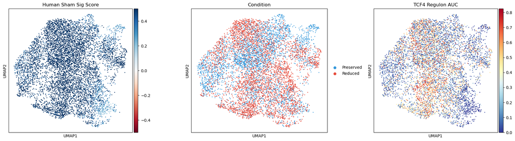

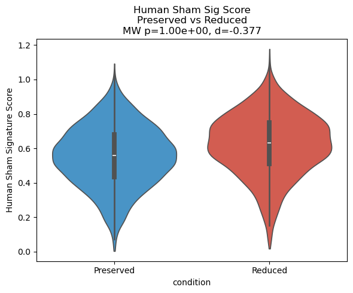

## 7. Save Annotated Human AnnData + Summary Table

```
✓ Saved: /Volumes/KT4TB_UG/Scanpy/Human_RV_Paper_Analysis/02_data/human/human_vascularEC_with_scenic_shamroot.h5ad
  Shape: (7637, 17064)
  New obs col: human_sham_sig_score

✓ Saved: /Volumes/KT4TB_UG/Scanpy/Human_RV_Paper_Analysis/04_figures/phase8_orthologs/TCF4_targets_crossspecies_overlap.csv
   mouse_gene human_ortholog  in_human_tcf4_targets
0       Arap3          ARAP3                  False
1    Arhgap27       ARHGAP27                  False
2     Ccdc85a        CCDC85A                  False
3        Dgkh           DGKH                  False
4        Dgkz           DGKZ                  False
5       Dock4          DOCK4                  False
6       Egfl7          EGFL7                  False
7        Etl4       KIAA1217                  False
8      Exoc3l        EXOC3L1                  False
9      Fam53b         FAM53B                  False
10      Fhod1          FHOD1                  False
11       Git2           GIT2                  False
12     Plxnd1         PLXND1                  False
13      Ptprm          PTPRM                  False
14    Rasgrp3        RASGRP3                  False
15     Sema6d         SEMA6D                  False
16      Sipa1          SIPA1                  False
17     Ushbp1         USHBP1                  False

=== Phase 8 Complete ===
Outputs:
  /Volumes/KT4TB_UG/Scanpy/Human_RV_Paper_Analysis/02_data/mouse/mouse_human_orthologs.csv
  /Volumes/KT4TB_UG/Scanpy/Human_RV_Paper_Analysis/02_data/mouse/human_sham_sig_genes.csv
  /Volumes/KT4TB_UG/Scanpy/Human_RV_Paper_Analysis/02_data/human/human_vascularEC_with_scenic_shamroot.h5ad
  /Volumes/KT4TB_UG/Scanpy/Human_RV_Paper_Analysis/04_figures/phase8_orthologs/TCF4_targets_crossspecies_overlap.csv
```